# Spotify and Billboard's Top 100 Songs

STOR 320.01

# INTRODUCTION

Billboard Magazine’s “Hot 100” songs of the week keeps track of the most popular and likeable singles in the United States at any given point in time. For a band or musician, making the list means exposure to more radio time and prolonged recognition throughout the music industry. Needless to say, a feature is a great milestone for any musical artist. So, is there a way to accurately quantify and predict the success of a song on this esteemed list?  
Spotify, the widely popular music streaming platform, assigns scores to what they call “audio features” for each song in their database. These features record concrete and arbitrary characteristics, such as a song’s genre, tempo, energy, danceability, etc. Using these numeric and categorical variables, we now have the opportunity to investigate the track attributes of all songs on the Billboard’s top 100 list.  
The first question we chose to examine was *what Spotify audio features, if any, can best predict if a song on Billboard will peak at the top ten of the list?* Answering this question helps us understand if the success of a song is a product of purely subjective factors, or if there are statistically significant numeric measurements that can influence a song’s popularity. Record producers and songwriters would be keen to know if certain audio features prove significant in the popularity of music. If so, they can attempt to adjust their music to more closely align with the Spotify feature profile of successful Billboard songs.  
Our second question had to do with the songs’ genre: *Are Spotify’s audio features sufficient in classifying the genre of a song in the Billboard’s top 100 list?* Streaming companies like Spotify, Pandora, and Sirius have playlists and stations for each genre and subgenre of music. As these services make music more accessible, they need to accurately and efficiently categorize their songs to keep their clientele satisfied. Given the subjective quality of music, having an accurate way to quantify a genre allows for a fast and automatic way to classify songs into their respective categories and playlists.

# DATA

Our data came from two main sources: Data.World and Spotify. From [Data.World](https://data.world/kcmillersean/billboard-hot-100-1958-2017), Sean Miller uploaded a CSV file with all Billboard Top 100 songs for each week from 1958 - 2019. He scraped Billboard’s website to collect the data using a web scraping service called [import.io](https://www.import.io/). This data contained a number of key variables, explained later below. After grabbing all songs, we then had to connect to Spotify’s public developer API to link each song with its respective Spotify audio features. This process was done in Python and involved querying the Spotify API for each song based on the song’s title and artist, and then querying the API again for each song’s audio features.  
This resulted in a dataset where each observation represented a song from the Billboard list at a specific week in time, along with the song’s respective audio features. The table below summarizes some of the key variables associated with each song that were pertinent to our study. It is important to note that most Spotify audio features are an algorithmic attempt to quantify a subjective quality of a song, such as “energy” or “instrumentalness.” Read more about the company that creates these proprietary algorithms, [here](https://en.wikipedia.org/wiki/The_Echo_Nest).

Key Variables

[output not shown]

After cleaning our data, we decided to use only the observations of songs present on the Billboard top 100 list between the years 2000 - 2019. This was done primarily to limit our study to those songs that are most similar to what people listen to today. This time range is long enough to allow us to examine trends in music over time, but not so long that our data contains songs vastly dissimilar to what is considered popular music today. It is important to note: songs and some of their features appear multiple times throughout the dataset. Since each observation is a song present on the Billboard list at a specific week in time, it is likely that many songs will still be present on the list from one week to the next. In many parts of our modeling, to account for this repetition, we grouped songs by name and artist to remove the duplicates. The minimum (best) `peak_pos` was selected when grouping the songs.

Example of a Duplicate Song

| week | song | artist | genre | peak_pos | speechiness | danceability |
| --- | --- | --- | --- | --- | --- | --- |
| 2019-05-04 | ME! | Taylor Swift Featuring Brendon Urie | pop | 100 | 0.0571 | 0.61 |
| 2019-05-11 | ME! | Taylor Swift Featuring Brendon Urie | pop | 2 | 0.0571 | 0.61 |
| 2019-05-18 | ME! | Taylor Swift Featuring Brendon Urie | pop | 2 | 0.0571 | 0.61 |
| 2019-05-25 | ME! | Taylor Swift Featuring Brendon Urie | pop | 2 | 0.0571 | 0.61 |
| 2019-06-01 | ME! | Taylor Swift Featuring Brendon Urie | pop | 2 | 0.0571 | 0.61 |
| 2019-06-08 | ME! | Taylor Swift Featuring Brendon Urie | pop | 2 | 0.0571 | 0.61 |
| 2019-06-15 | ME! | Taylor Swift Featuring Brendon Urie | pop | 2 | 0.0571 | 0.61 |
| 2019-06-22 | ME! | Taylor Swift Featuring Brendon Urie | pop | 2 | 0.0571 | 0.61 |

Example of Grouping of the Duplicate Song

| song | artist | genre | peak_pos | speechiness | danceability |
| --- | --- | --- | --- | --- | --- |
| ME! | Taylor Swift Featuring Brendon Urie | pop | 2 | 0.0571 | 0.61 |

In the end, our dataset contained a total of over 100,000 entries. When grouping by song and artist name we were left with 7,707 unique songs. Of these, 212 songs were missing Spotify audio feature data and had to be discarded when we ran our model and analysis. This missing data was primarily due to the songs not being available on Spotify, or because their artist name on the Billboard list was not identical to the artist name that was recorded by Spotify. After removing data with missing values, we were left with *99,784 total observation and 7,495 unique songs*.

[figure not shown]

# RESULTS

**Audio Features to Predict a Song’s Peak Position:**

The first inquiry we set out to investigate questioned the robustness of similarities in audio features for songs that peak in the top 10. More specifically, we wanted to know if it is possible to predict whether or not a song would “qualify” for a top 10 ranking based solely on its audio features.

**Methodology:**

First, the data was split into “TRAIN” and “TEST” groups, at a proportion of 85% to 15%, respectively. The first model that was built used all of the audio features in their original state (no transformations) to predict the outcome variable, Peak Position. Given the model summary, it was evident that transformations would be needed, as the R-squared was noticeably low (<.01), and the residual plots were far from being normally distributed. It is also worth noting that this model summary did not indicate any statistical significance for any of the audio features. The `regsubsets()` function was then employed to identify which of the features were “most important” in terms of predicting peak position. Mallows’s Cp was calculated to show which subset of predictor variables would best be used together, and which variables should be considered for exclusion.  
From here, around ten different models were built using combinations of logistic, exponential, root, and polynomial transformations, including interaction terms between variables that were related— all evaluated with the training data. Very few models indicated any statistical significance, and the ones that did ranked poorly in RMSE and returned negative values for R-squared that were also less than .01.

The top 5 models were chosen for evaluation:

*(X(i) indicates the variable was used in interaction)*

Top 5 Model Summaries

| Model | MODEL1 | MODEL2 | MODEL3 | MODEL4 | MODEL5 |
| --- | --- | --- | --- | --- | --- |
| Output Variable: Peak Position | X | log(X) | e^X | X | X |
| Danceability | X | X | X | NA | X, X^2, X(i) |
| Energy | X | X^2 | X | X | X, X(i) |
| Speechiness | X | X | X | X | X, X^2 |
| Liveness | X | X^2 | X | NA | NA |
| Acousticness | X | X | X | NA | X, X^2 |
| Instrumentalness | X | NA | X | NA | X^2 |
| Valence | X | X | X | X | X, X^2 |
| Tempo | X | X | X | NA | X |
| Duration | X | X^2 | X^2 | NA | X^2 |
| RMSE TRAIN | 3.018854 | 3.217096 | 4.15302 | 3.041115 | 2.98002 |
| RMSE TEST | 3.055655 | 3.336312 | 4.252235 | 2.9714 | 3.1707 |
| R-Squared | -0.01241 | 0.01865 | 0.01099 | 0.005742 | -0.01356 |

The red indicates **TRAIN** points and the blue indicate **TEST** points.

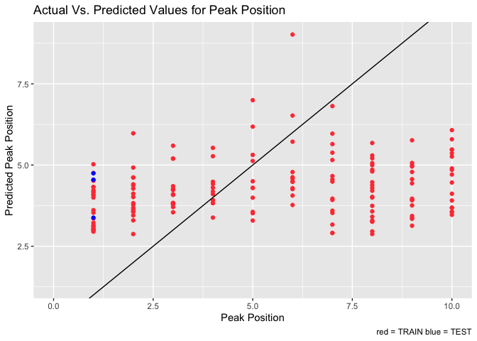

**Takeaways:**

Based on the results from the methods used to test model effectiveness, our “best model” proved to be extremely ineffective in predicting Peak Position. An R-squared value of .01865 indicates that only 1.87% of the variation in the data is explained by our predictor variables. Additionally, none of the coefficients in the model were statistically significant and the residual distribution remained fairly unchanged. Based on these model characteristics, along with the validation results, it can be concluded that audio features alone cannot predict a song’s popularity. When applied to the “real world,” this makes sense— people listen to music that appeals to their emotions. More qualitative characteristics, such as genre, artist, and lyrics, play a significant role in the popularity of music, which were purposefully not included in these models. Additionally, there are no significant differences in the audio features of “top 10” songs as opposed to those ranked between 11 and 100 on the charts. Based on our model, Spotify’s audio features are seemingly unimportant to a song’s rise to “top 10” popularity.

**Genre Classification:**

Two main methods were pursued to assess the useability of Spotify audio features in genre classification: a random forest decision tree model and several logistic regression models. Due to sparsity in observations for most genres, we chose to focus our models on the 3 most popular genres in our data set. These include pop, rap, and country songs.

**Random Forest Classifier:**

First, the data was split into training and testing sets. Using the training set, a random forest cross validation function was applied (fold = 5) to determine which variables had the best predictive performances on the genre of a song *(see graphic below)*. From this, it was determined that all 10 audio features (not including song duration) were potentially significant, as each variable reduced the error in the cross validated predicted performance. Using these variables and the random forest package, 500 decision trees were generated and amassed to form a random forest classification model, with 3 variables used at each split for each decision tree. Finally, the test data was used to assess the accuracy of the model.

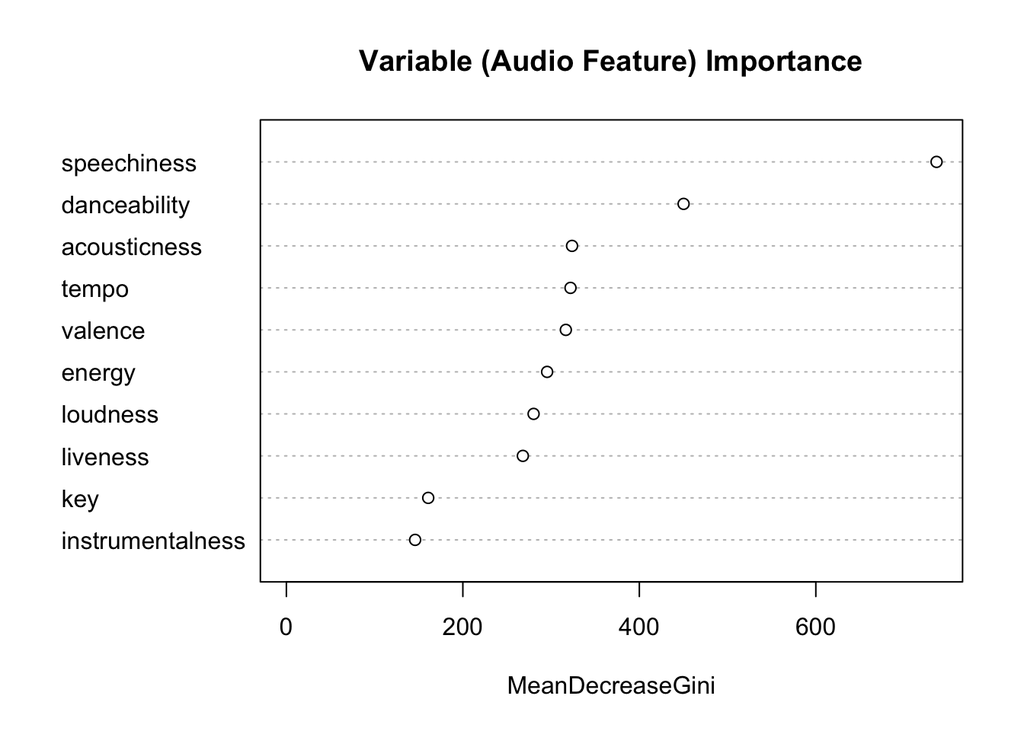

Accuracy of Random Forest Classifier

| Genre | Predicted to Be: Country | Predicted to Be: Rap | Predicted to Be: Pop | Total Number of Songs | Error |
| --- | --- | --- | --- | --- | --- |
| country | 371 | 13 | 531 | 915 | 0.5945355 |
| rap | 10 | 1140 | 571 | 1721 | 0.3375944 |
| pop | 219 | 460 | 2154 | 2833 | 0.2396753 |

As seen in the *table above*, the pop genre had the smallest prediction error while country songs, more often than not, were misclassified. Interestingly, this misclassification of country songs was primarily associated with pop and almost never included rap. This suggests that there are significantly stark differences in the composition of audio features for rap and country songs, but not for pop and country songs. Still, part of the bias towards pop classification could be attributed to the much larger proportion of pop songs than the other two genres. Pop songs were misclassified roughly 25% of the time while country songs had an error of almost 60%. Overall, the combined effect of all Spotify audio features proved decent in classifying pop and rap songs, but was not enough to discern between pop and country songs.

**Logistic Regression:**

Given our results for our random forest classifier, we wanted to see if specific audio features were more influential than others for each specific genre. For each genre, we initialized `glmnet()` models with various alpha values (0, .25, .5, .75, 1) and x parameters that included the Spotify audio features. We obtained cross-validation error by testing different lambda values and used the combination with the largest lambda within one standard deviation of the error. Then, we created a new predictive model for each genre using the best alpha/lambda combination. For the country genre, this model consistently predicted “No” for all songs. This behavior was probably due to the much smaller sample of country songs when compared to the other two genres. As an alternate method, the data was split into train and test groups (80% and 20% respectively) and the `glm()` function was employed to classify country songs. For all models, the binary cut-off value for classification within a genre was 0.5 (< 0.5 = “No”, > 0.5 = “Yes”).

Statistically Significant Variables of Rap, Pop, and Country Songs

|  | Rap/Hip Hop | Pop | Country |
| --- | --- | --- | --- |
| speechiness | √ | √ | √ |
| danceability | √ | √ | √ |
| tempo |  | √ | √ |
| valence | √ | √ | √ |
| acousticness | √ |  | √ |
| energy |  |  | √ |
| loudness |  | √ | √ |
| liveness | √ |  | √ |
| key |  |  |  |
| instrumentalness | √ |  | √ |

These separate models resulted in different variables proving significant for classifying different genres. Importantly, the audio features that proved most significant in our random forest model (speechiness and danceability) also appear significant across all genres in these logistic models. That being the case, it seems that audio features themselves are still not fully sufficient in accurately classifying a song within a single genre. With a precision rate of 7% and overall accuracy of only 14%, the country model heavily favored positive classification of songs. Similarly, the rap model over classified songs as belonging to the rap genre (precision = 21%, accuracy = 22%). These results suggest that the numeric values of different audio features across genres are too similar to provide a meaningful source for classification.

Pop Model Confusion Matrix

|  | Predicted: Yes | Predicted: No |
| --- | --- | --- |
| Actual: Yes | 2708 | 809 |
| Actual: No | 1598 | 1706 |

Rap/Hip Hop Model Confusion Matrix

|  | Predicted: Yes | Predicted: No |
| --- | --- | --- |
| Actual: Yes | 1116 | 1042 |
| Actual: No | 4268 | 395 |

Country Model Confusion Matrix

|  | Predicted: Yes | Predicted: No |
| --- | --- | --- |
| Actual: Yes | 384 | 790 |
| Actual: No | 5075 | 572 |

# CONCLUSION

Going into our analysis we had two questions: *what Spotify audio features best predict if a song peaks on the top 10 hits on the Billboard Hot 100 list*, and *can those audio features classify songs into their respective genres?* Our results proved that none of Spotify’s audio features were good predictors of a song’s peak position on the Billboard list. Additionally, those same audio features, in large, were lousy predictors of a song’s genre. We initially assumed there would be some correlation between a song’s audio features and its peak position (popularity) on the charts because many songs that reach high positions tend to be upbeat, fast, and danceable. Similarly, songs of a particular genre of music tend to have similar tempos, rhythms, and overall music structure, which we thought would be captured by the songs respective audio features.  
Our results seem to suggest that a song’s popularity and genre are made up of more Spotify’s audio features. Spotify’s attempts at quantifying the subjective and intangible aspects of a song, such as its “energy” and “danceability,” are not enough to account for the differences in peak position across the charts. While many of these audio features were deemed significant in classifying a song’s genre, the low accuracy of many of our models point to the fact that there is much more at play when holistically determining the genre of a song. For record producers and musicians, this means Spotify’s audio features are not a good foundation to work off of when attempting to emulate the chart-topping hits. For streaming companies that need to classify songs into playlists and genre categories, our results suggest that they should not rely purely on objective measurements (like tempo or loudness) and subjective audio features. Indeed, a more complicated algorithm would need to be put in place to accurately categorize a song into its correct genre.  
There is still much that can be done and expanded upon with this analysis. Our evaluation of the popularity (peak position) of songs was limited to only those singles that were already on the Billboard list. It could be that the difference between a #90 hit and a #10 hit simply isn’t that large. But, when comparing a hit single to any random non-Billboard song, perhaps the difference in audio feature values is significant. This study could benefit from randomly sampling additional non-hit singles to deepen our dataset. A more genre-balanced data set could also potentially improve the accuracy of our genre classification models. Aside from adding data, future studies could examine other indicators of song success. Perhaps audio features can better predict the number of weeks a song stays on the charts, or the number of Spotify listens/streams a song receives.